# Week 5: Visualising Random Processes

161.307 Reproducible Visualisation for Statistics

School of Mathematical and Computational Sciences, Massey University

10 Aug 2026

## The plan for this week

- Lecture 1: Why and how we simulate
- Lecture 2: Visualising many realisations
- Tutorials: from a single trajectory to ensembles and ribbons

This week, we set up the visual grammar (spaghetti plots, small multiples, ribbons) that Week 6 will reuse for *statistical* uncertainty.

# Lecture 1: Why and how we simulate

## Reproducibility and randomness

A contradiction in terms? Not if we’re careful.

```r
set.seed(2025)
rnorm(5)
```

```
[1] 0.6207567 0.0356414 0.7731545 1.2724891 0.3709754
```

```r
set.seed(2026)
rnorm(5)
```

```
[1]  0.52058907 -1.07969076  0.13923812 -0.08474878 -0.66663962
```

- `set.seed()` makes “random” output reproducible
- Document the seed, the RNG kind (`RNGkind()`; see `help("RNG")` if you are curious), and package versions (`sessionInfo()` / `renv`): this *is* reproducible visualisation

## Reproducibility and randomness

Notice:

```r
set.seed(2026)
rnorm(5)
```

```
[1]  0.52058907 -1.07969076  0.13923812 -0.08474878 -0.66663962
```

```r
set.seed(2026)
rnorm(5, mean = 0, sd = 1)
```

```
[1]  0.52058907 -1.07969076  0.13923812 -0.08474878 -0.66663962
```

```r
set.seed(2026)
rnorm(3)
```

```
[1]  0.5205891 -1.0796908  0.1392381
```

```r
set.seed(2026)
rnorm(7)
```

```
[1]  0.52058907 -1.07969076  0.13923812 -0.08474878 -0.66663962 -2.51608903
[7] -0.73514680
```

## Why simulate at all?

- To understand a model’s behaviour before fitting it to data
- To generate “what could have happened”: a distribution of possible outcomes from a single set of assumptions
- To stress-test a visualisation: does it still work with 10, 100, 10000 realisations?

We’ll take each of these in turn, with a real-world example and a small numerical experiment.

## Types of random processes we’ll use

- **Random walk**: $X_{t} = X_{t-1} + \varepsilon_t$
- **Point process**: random arrival times (e.g. Poisson process)
- **Simple birth–death / count process**: a light precursor to the epidemic models in Weeks 7-8

## Why simulate? (1) Understand behaviour before fitting

- Before you fit a model to real data, simulate from it. Does it produce trajectories that even *look* like the phenomenon you’re studying?
- Real life $\# 1$: climate scientists run their models under a range of plausible parameters before calibrating against observations, partly to check the model isn’t capable of producing physically nonsensical output
- Real life $\# 2$: an epidemiologist chooses a starting $R_0$ and checks the resulting epidemic curve looks plausible *before* fitting the model to real case counts. Fitting a badly-specified model to data can still “succeed” numerically while being meaningless
- This is a **diagnostic** use of simulation, not an inferential one: we’re building intuition, not yet estimating anything

## Numerical experiment: does this random walk look like a river?

`datasets::Nile` gives annual flow of the Nile at Aswan, from 1871 to 1970

```r
library(ggplot2)

nile_df <- data.frame(year = as.numeric(time(Nile)), flow = as.numeric(Nile))

ggplot(nile_df, aes(year, flow)) +
  geom_line() +
  labs(title = "Real data: Nile annual flow, 1871-1970",
       x = "Year", y = "Flow") +
  theme_minimal()
```

## Numerical experiment: does this random walk look like a river?

`datasets::Nile` gives annual flow of the Nile at Aswan, from 1871 to 1970

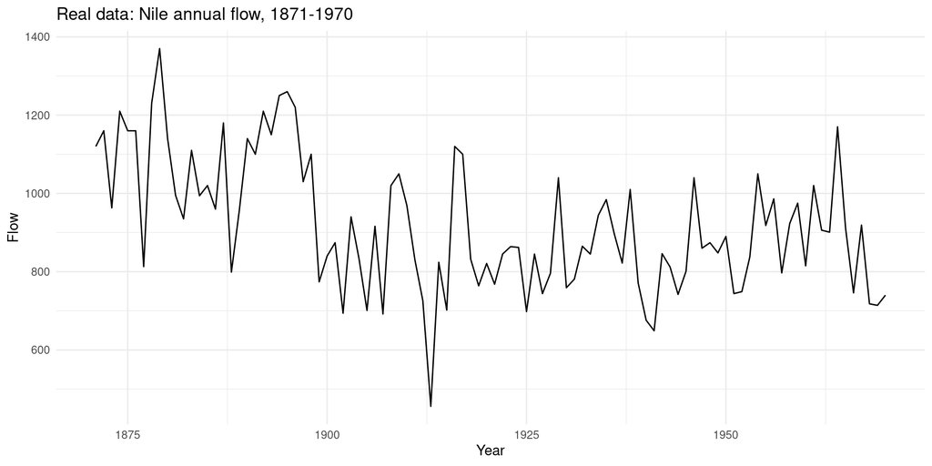

## A simple random walk

$X_{t} = X_{t-1} + \varepsilon_t$, with $\epsilon_t \sim \mathrm{Normal}(0,1)$.

```r
library(ggplot2)
set.seed(2026)
max_time <- 100
time     <- 1:max_time
position <- numeric(max_time)
position[1] <- rnorm(1) # first time point
for (t in 2:max_time) {
  position[t] = position[t-1] + rnorm(1)
}
walk <- data.frame(time=time, position=position)

ggplot(walk, aes(time, position)) +
  geom_line() +
  labs(title = "A single random walk realisation",
       x = "Time", y = "Position") +
  theme_minimal()
```

## Simple random walk: a single realisation

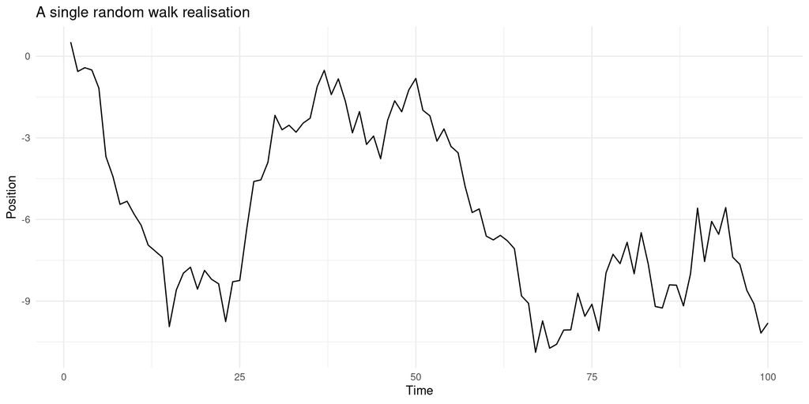

## A simple random walk: four realisations

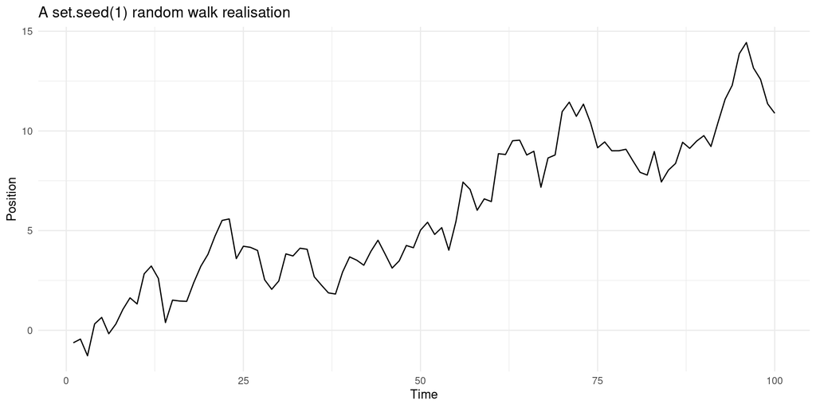

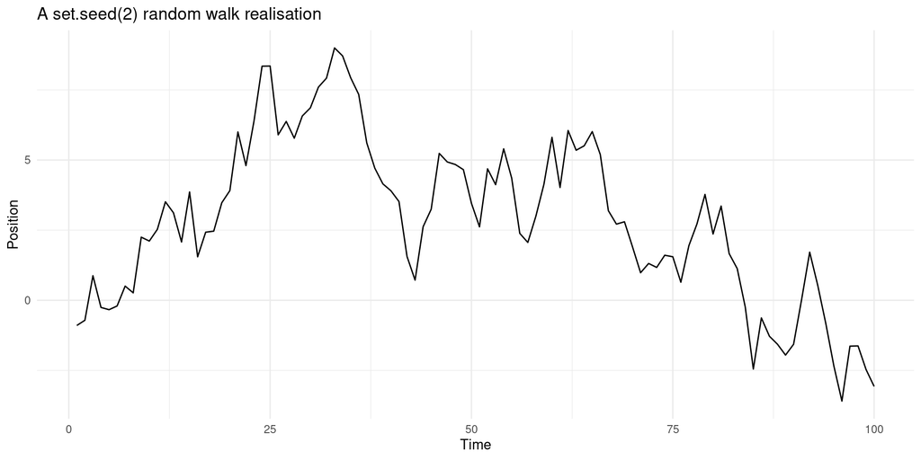

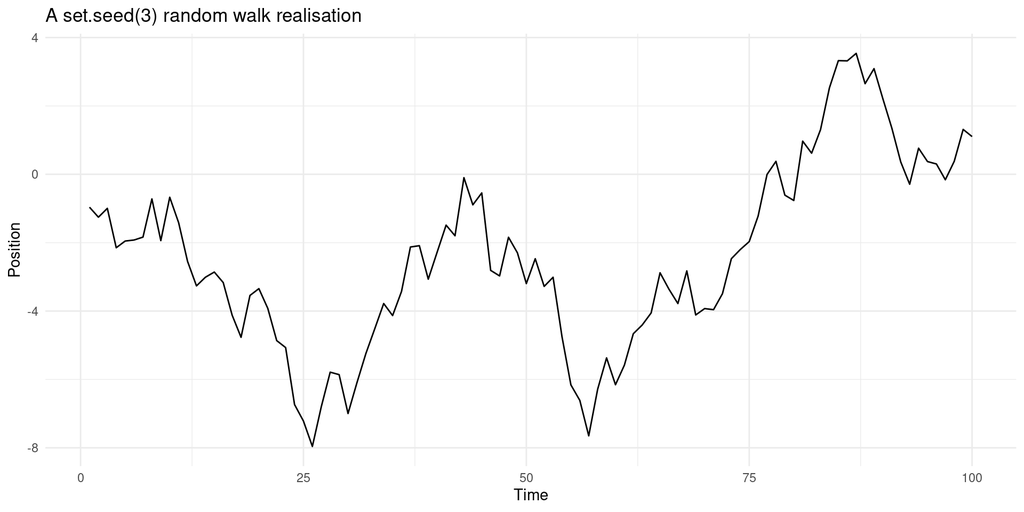

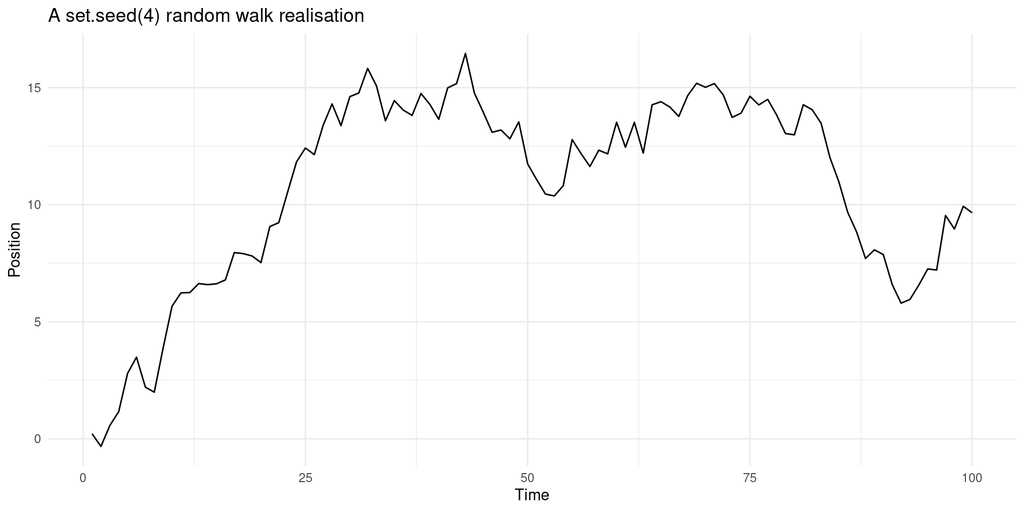

## Numerical experiment: 3 candidate simulators

```r
set.seed(2026)
n  <- length(Nile)
mu <- mean(Nile)

compare_df <- data.frame(year = rep(nile_df$year, 3+1),
                         flow = c(nile_df$flow,
           mu + cumsum(rnorm(n, sd = 100)),
           mu + cumsum(rnorm(n, sd = 200)),
           mu + cumsum(rnorm(n, sd = 800))),
  series = rep(c("Real Nile data", "Sim: sd = 100", "Sim: sd = 200" ,"Sim: sd = 800"), each = n)
)

ggplot(compare_df, aes(year, flow, colour = series)) +
  geom_line(show.legend = FALSE) +
  facet_wrap(~ series, ncol = 1, scales = "free_y") +
  labs(title = "Which simulated walk looks plausible before we fit anything?",
       x = "Year", y = "Flow") +
  theme_minimal()
```

## Numerical experiment: 3 candidate simulators

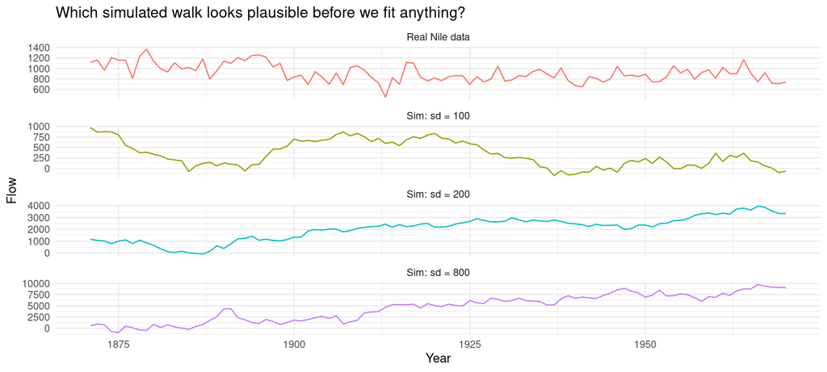

- We’re not trying to match the real series exactly. We just ask whether the *qualitative* behaviour (smoothness, typical step size) is in the right ballpark before committing to formal estimation

## Why simulate? (2) “What could have happened”

- A single observed history is *one draw* from a huge space of outcomes consistent with the same assumptions
- Real life $\# 2$b: outbreak investigators simulate a stochastic epidemic many times from the same $R_0$ and starting conditions to ask “how often does an outbreak like this fizzle out on its own, versus take off?”. This tells them whether a (reassuringly?) small early case count is actually reassuring (!)
- Real life $\# 3$: insurers and reinsurers simulate thousands of possible claims scenarios from one risk model to price a policy, precisely because only one future will actually be observed
- The point: from a *single set of assumptions* we get a *distribution* of outcomes, not one precise prediction

## Poisson process: a simple building block

- Events occur one at a time, at some rate $\lambda$, independently of one another
- Time between events $\sim \text{Exponential}(\lambda)$; the number of events in a fixed window of length $T$ is $\sim \text{Poisson}(\lambda T)$
- Real life examples: call-centre calls, server requests, radioactive decay counts, customer arrivals in a bank…All commonly modelled this way
- Let’s warm-up with a single realisation later before committing to the outbreak example (Real life $\# 2$b)

## Poisson process: a single realisation

### How long before we serve 30 customers?

Same rate every time, but each waiting time is a separate draw, so the total *observed* time varies

```r
set.seed(2026)
lambda <- 2 # feel free to play with this
arrivals <- cumsum(rexp(30, rate = lambda))

events <- data.frame(time = arrivals, event = 1:length(arrivals))

ggplot(events, aes(time, event)) +
  geom_step() +
  geom_point() +
  labs(title = "Poisson process as cumulative event count",
       x = "Time", y = "Number of events") +
  theme_minimal()
```

## Poisson process: a single realisation

### How long before we serve 30 customers?

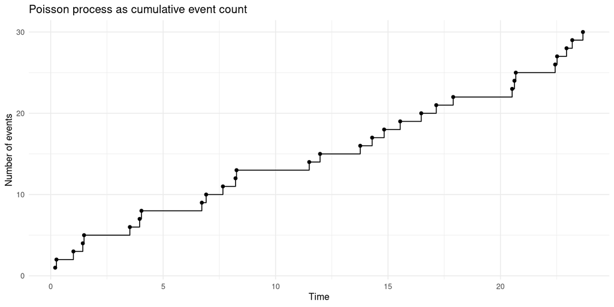

## A Poisson process: four realisations

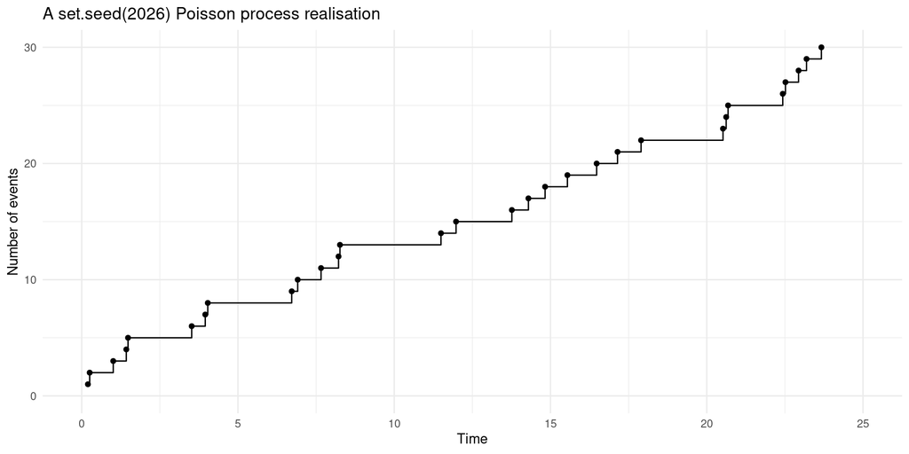

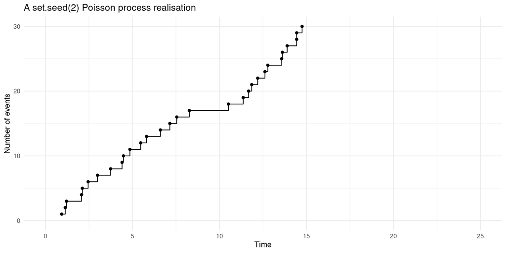

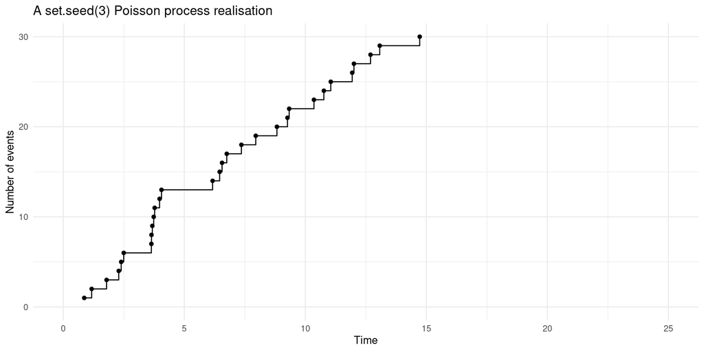

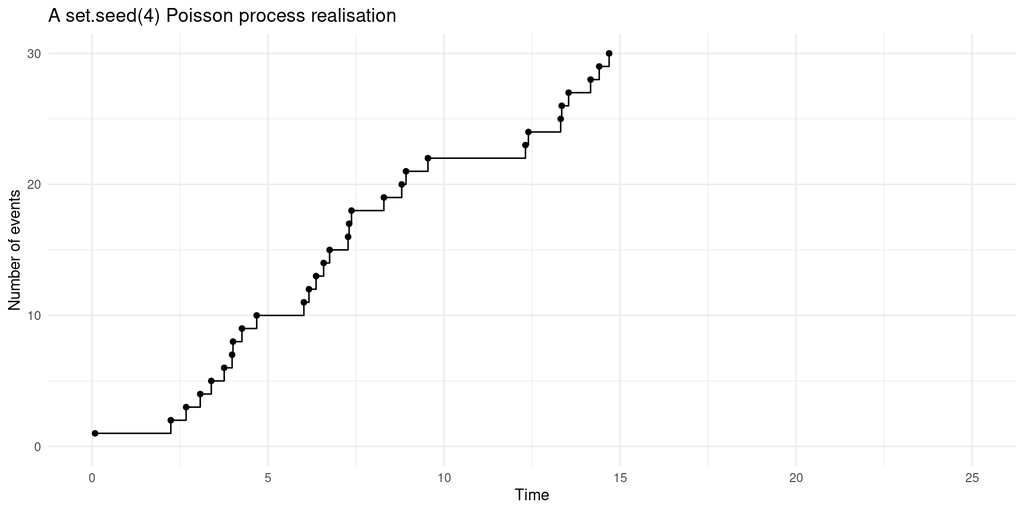

## Poisson process: a complementary point of view

### How many client arrivals in 8 hours?

Same rate every time, but each eight-hour window is a separate draw, so the *observed* count still varies

```r
set.seed(2026)
lambda <- 2 # events per hour, on average
n_windows <- 365 # one year of observations

counts <- rpois(n_windows, lambda = 8*lambda)

ggplot(data.frame(count = counts), aes(count)) +
  geom_bar() +
  labs(title = paste0(n_windows, " repeated days, rate = ", lambda),
       subtitle = "Same rate every day, count varies",
       x = "Number of clients", y = "Day count") +
  theme_minimal()
```

## Poisson process: a complementary point of view

### How many client arrivals in 8 hours?

[figure not shown]

- This is the “what could have happened” idea in its simplest form: one fixed rate, many possible counts.
- You could have random rates $\to$ more uncertainty

## Numerical experiments: a disease outbreak

- We introduce a process where each arrival can itself trigger further arrivals: a branching process. This is exactly how an epidemic outbreak behaves
- A simple branching process: each new or still present case infects a Poisson-distributed number of others with mean $R_0$.

```r
simulate_ONE_outbreak <- function(R0 = 1.2, max_gen = 20) {
  cases <- rep(0, max_gen)
  cases[1] <- 1; total <- 1
  for(gen in 1:(max_gen-1)){
    if(cases[gen] > 0){
      cases[gen+1] <- sum(rpois(cases, lambda = R0))
      }else{
      break
    }
  }
  cases
}
```

## Numerical experiments: a disease outbreak

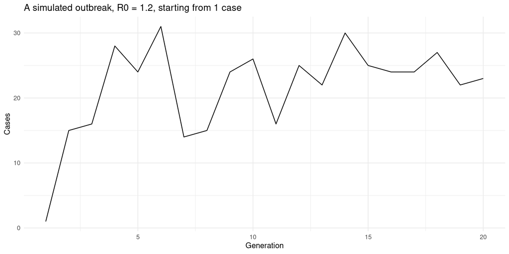

```r
set.seed(2026)
cases <- simulate_ONE_outbreak()

ggplot(data.frame(gen = 1:length(cases), cases = cases)) +
  aes(x = gen, y = cases) +
  geom_line() +
   labs(title = "A simulated outbreak, R0 = 1.2, starting from 1 case",
       x = "Generation", y = "Cases") +
  theme_minimal()
```

## Numerical experiment: 2000 identical outbreaks

- Next, we scale this up to 2000 “identically distributed” outbreaks and study the final total size

```r
set.seed(2026)

simulate_outbreak <- function(R0 = 1.2, max_gen = 20) {
  cases <- 1; total <- 1; gen <- 0
  while (cases > 0 && gen < max_gen) {
    new_cases <- sum(rpois(cases, lambda = R0))
    total <- total + new_cases
    cases <- new_cases
    gen <- gen + 1
  }
  total
}
```

## Numerical experiment: 2000 identical outbreaks

```r
outbreak_sizes <- replicate(2000, simulate_outbreak())
```

```r
ggplot(data.frame(size = outbreak_sizes), aes(size)) +
  geom_histogram(bins = 30) +
  scale_y_log10() +
  labs(title = "2000 simulated outbreaks, all with R0 = 1.2, starting from 1 case",
       subtitle = "Identical assumptions, wildly different outcomes",
       x = "Final outbreak size", y = "Count") +
  theme_minimal()
```

## Numerical experiment: 2000 identical outbreaks

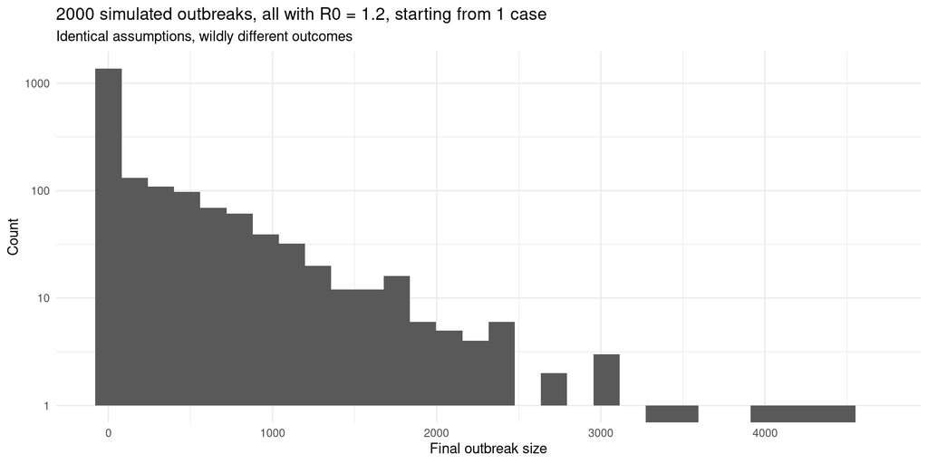

## Numerical experiment: 2000 identical outbreaks

- Most runs fizzle out almost immediately (size = 1); others grow large….or huge! Same $R_0$, same starting point, every time
- No amount of staring at *one* simulated (or real) outbreak reveals this: you need the ensemble

## Why simulate? (3) Stress-test a visualisation

- A plot design that reads nicely with 10 lines can become useless at 10,000- you only find out by trying
- Real life $\#2$c: COVID-19 dashboards went from tracking a handful of regional case trajectories in early 2020 to thousands a year later; designs that worked at launch had to be redesigned (towards summaries: ribbons, heatmaps) as volume grew
- **Real life:** Monte Carlo risk dashboards must stay interpretable whether a scenario run has 100 or 100,000 simulated paths
- Simulation lets you generate that stress test *before* real data volume forces the issue on you

## Why simulate? (3) - testing before it costs you

That last point is really about *timing*, not just aesthetics:

- Real data volume arrives on its own schedule. You don’t choose when your dataset grows from 50 rows to 50,000 (or more)
- If the failure only shows up once real volume gets there, you find out in front of a “client”, in a live dashboard, or the night before a deadline
- Simulating in advance means the failure happens quietly, on your own laptop, while there’s still time to redesign calmly
- It’s **cheap**: generating 10,000 fake rows takes seconds. Waiting for 10,000 real rows might take months
- You can probe scenarios real data hasn’t produced *yet*: what if usage doubles overnight? What if every request arrives in the same second? The design is tested against the future. Your imagination is the limit

**Rule of thumb:** if a report or dashboard might ever need to scale up, simulate the scaled-up version *now*, while redesigning is still cheap.

## Numerical experiment: the same plot at three scales

```r
library(patchwork)
library(dplyr)

make_sims <- function(n_sims, n_steps = 100, seed = 1) {
  set.seed(seed)
  # generate the list of data frames
  sim_list <- lapply(1:n_sims, function(i) {
    data.frame(sim = i, time = 1:n_steps, position = cumsum(rnorm(n_steps)))
  })
  # bind them together directly
  bind_rows(sim_list)
}

plot_sims <- function(n_sims) {
  ggplot(make_sims(n_sims), aes(time, position, group = sim)) +
    geom_line(alpha = 0.3) +
    labs(title = paste0("n = ", n_sims)) +
    theme_minimal()
}

plot_sims(10) + plot_sims(100) + plot_sims(10000)
```

## Numerical experiment: the same plot at three scales

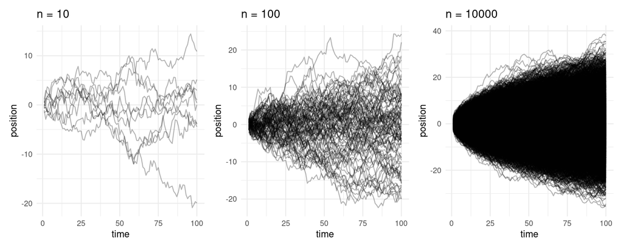

## Numerical experiment: the same plot at three scales

- $n=10$: individual trajectories are still readable
- $n=100$: we lose track of individual lines, but the overall density is still informative
- $n=10\,000$: the plot is essentially a smudge — at this scale we need a different idiom entirely (ribbons, 2D density), which is exactly where Lecture 2 goes next

## Visual idioms for random processes

| Idiom | What it shows | Risk |
| --- | --- | --- |
| Trace / line plot | One realisation over time | Implies “the” outcome |
| Spaghetti plot | Many overlaid realisations | Overplotting |
| Small multiples (facets) | Many separate panels | Doesn’t scale past ~10-20 |
| Animation | Sequential realisations | Hard to compare, not reproducible as a static figure |

## Lecture 1: summary

- **Reproducibility and randomness**: `set.seed()` makes “random” output reproducible: show document seed, RNG kind, and package versions
- **Why simulate at all?**
  - Understand a model’s behaviour *before* fitting it
  - Generate “what could have happened”: a distribution of outcomes from one fixed set of assumptions
  - Stress-test a visualisation before real data volume forces the issue on you
- **Types of random processes**: random walk, Poisson (point) process, simple branching/birth–death process
- **A first visual idiom problem**: a single trace looks fine; three or four is fine; 10,000 realisations breaks a naive line plot

## Looking ahead: Lecture 2

Every example above quietly ran into the same wall: once you have *many* realisations, how do you actually plot them well?

- The **overplotting problem**: what happens to a spaghetti plot as $n$ grows
- **Small multiples** as a partial fix…and where that idiom itself breaks down
- **Quantile ribbons**: summarising an ensemble by its median and central bands, rather than drawing every line
- **Visual vs statistical variability**: a ribbon answers a *statistical* question (“how wide is the plausible range?”) using a *visual* encoding. This distinction returns in Week 6, this time to estimate uncertainty rather than to simulate variability
- **Choosing between idioms**: spaghetti vs ribbon, and what each one hides

# Lecture 2: Visualising many realisations

## The overplotting problem

$\to$ 200 realisations of 100-steps random walks

```r
set.seed(2026)
n_steps <- 100
n_sims  <- 200

sims <- lapply(1:n_sims, function(i) {
  data.frame(sim = i, time = 1:n_steps,
             position = cumsum(rnorm(n_steps)))
}) |> bind_rows()
```

```r
ggplot(sims, aes(time, position, group = sim)) +
  geom_line(alpha = 0.05) +
  labs(title = "200 random walks") +
  theme_minimal()
```

## The overplotting problem

$\to$ 200 realisations of 100-steps random walks

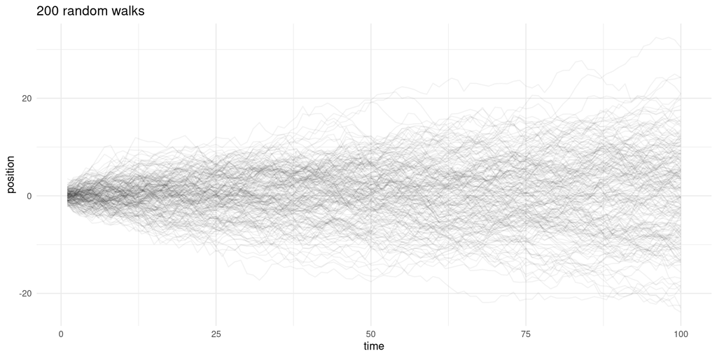

## The overplotting problem

$\to$ 2000 realisations of 100-steps random walks (oh my hair!)

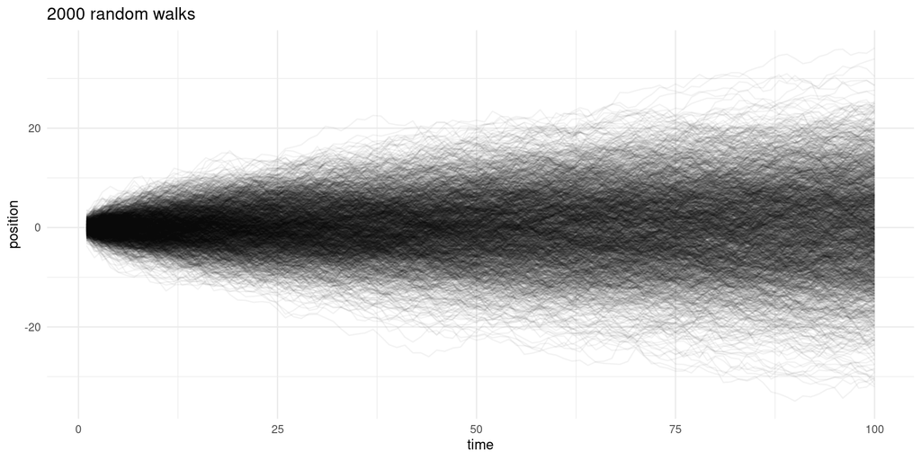

## Small multiples as an alternative

```r
subset_sims <- subset(sims, sim <= 9)

ggplot(subset_sims, aes(time, position)) +
  geom_line() +
  facet_wrap(~ sim) +
  labs(title = "9 of 2000 realisations") +
  theme_minimal()
```

## Small multiples as an alternative

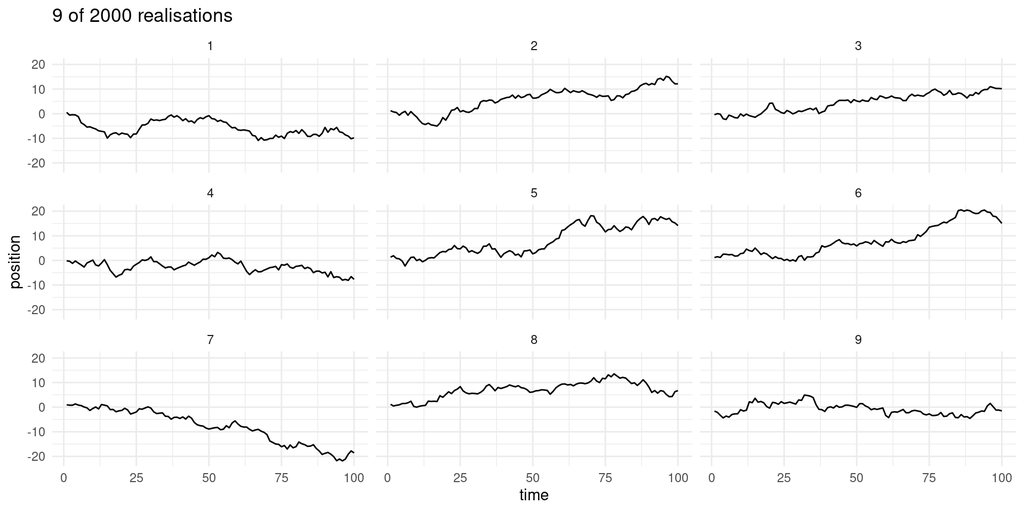

- Good for showing *variety* of individual trajectories
- Bad for showing the *overall envelope*. It does not scale to 2000 or even 200 panels

## One panel highlighting a few realisations within the full ensemble,

### Overlaying a small multiple on the mop hair

```r
ggplot() +
  geom_line(data = sims, aes(time, position, group = sim),
            colour = "grey80", alpha = 0.15) +
  geom_line(data = subset_sims, aes(time, position, colour = factor(sim)),
            linewidth = 0.9) +
  labs(title = "9 highlighted realisations within all 200",
       colour = "Realisation") +
  theme_minimal()
```

- grey background: overall spaghetti envelope
- Nine coloured lines for individual trajectory identification

## Highlighting a few realisations within the full ensemble,

### Overlaying a small multiple on the mop hair

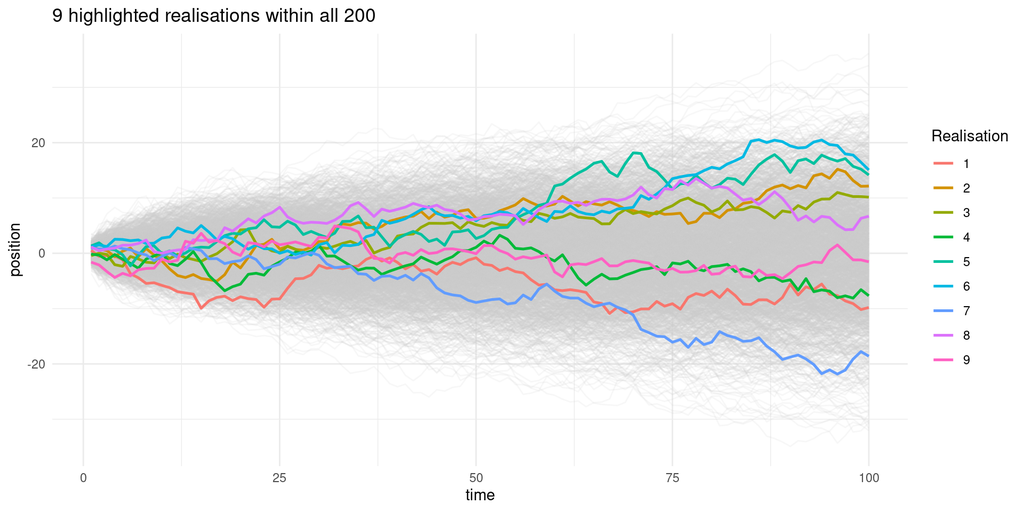

- Why 9? What’s left out?
- Colour readibility?
- What if 2,000 grows? How does it scale?

## Summarising the ensemble: quantile ribbons

```r
summary_df <- sims |>
  group_by(time) |>
  summarise(
    median = median(position),
    lower50 = quantile(position, 0.25),
    upper50 = quantile(position, 0.75),
    lower90 = quantile(position, 0.05),
    upper90 = quantile(position, 0.95)
  )

ggplot(summary_df, aes(time)) +
  geom_ribbon(aes(ymin = lower90, ymax = upper90), alpha = 0.2) +
  geom_ribbon(aes(ymin = lower50, ymax = upper50), alpha = 0.4) +
  geom_line(aes(y = median), linewidth = 1) +
  labs(title = "Median, 50% and 90% bands across 2000 realisations",
       y = "Position") +
  theme_minimal()
```

## Summarising the ensemble: quantile ribbons

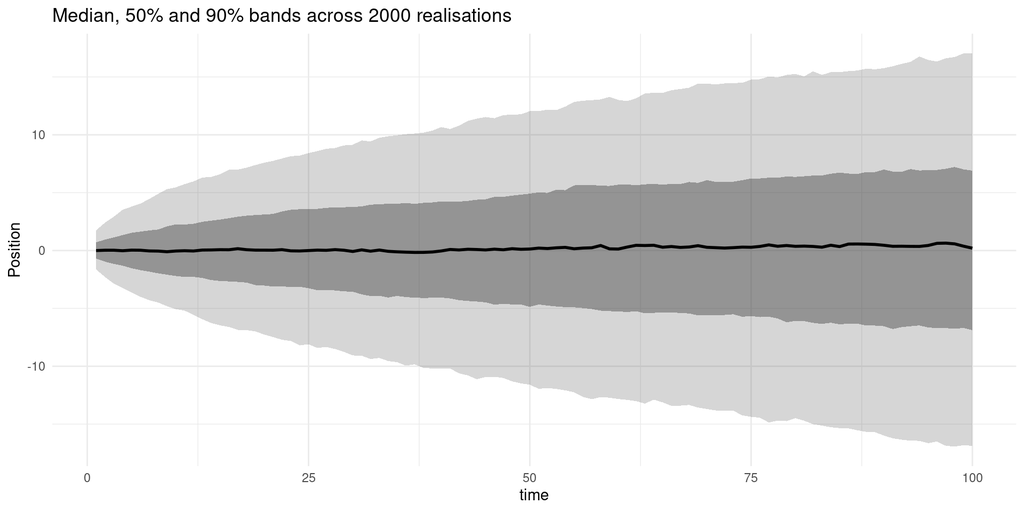

## Visual variability vs statistical variability

- A single “wiggly” trajectory might *look* unusual but be entirely consistent with the model
- A ribbon answers: “how wide is the range of plausible outcomes at time $t$?”. This is a **statistical** question answered with a **visual** encoding
- Keep this distinction in mind: in Week 6 the ribbon will represent uncertainty of an *estimation*, not variability of *simulations*
  - Same visual grammar, different meaning underneath

## What the ribbon hides: a single path is not “noise inside a band”

```r
one_path <- subset(sims, sim == 1)

ggplot(summary_df, aes(time)) +
  geom_ribbon(aes(ymin = lower90, ymax = upper90), alpha = 0.2) +
  geom_ribbon(aes(ymin = lower50, ymax = upper50), alpha = 0.4) +
  geom_line(aes(y = median), linewidth = 1) +
  geom_line(data = one_path, aes(y = position),
            colour = "firebrick", linewidth = 0.8) +
  labs(title = "A single realisation overlaid on the ribbon",
       y = "Position") +
  theme_minimal()
```

## What the ribbon hides: a single path is not “noise inside a band”

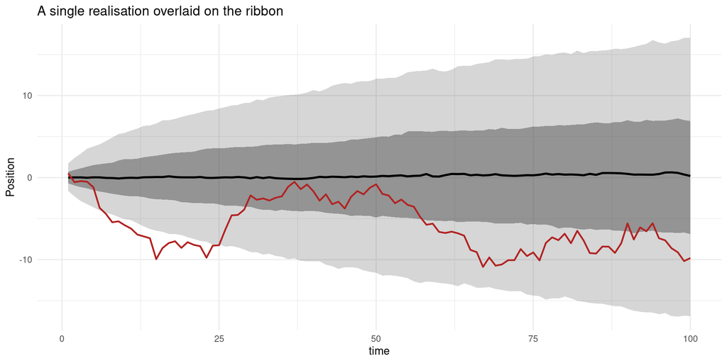

## What the ribbon hides: a single path is not “noise inside a band”

- Ribbon built from **independent draws at each t**
- Ribbon shape says nothing about one (auto-correlated) path which “moves through” that range
- One path drifts, and can hug one edge for long stretches
- **In real life we usually only ever see one time series** (Nile data)
  - the ribbon shows the envelope of plausibles, not how bizarre any single observed path is expected to look like

## Choosing between idioms

```r
library(patchwork)

p1 <- ggplot(sims, aes(time, position, group = sim)) +
  geom_line(alpha = 0.03) +
  labs(title = "Spaghetti (n = 200)") + theme_minimal()

p2 <- ggplot(summary_df, aes(time)) +
  geom_ribbon(aes(ymin = lower90, ymax = upper90), alpha = 0.3) +
  geom_line(aes(y = median)) +
  labs(title = "Ribbon (median + 90%)") + theme_minimal()

p1 + p2
```

## Choosing between idioms

[figure not shown]

## Choosing between idioms

- Spaghetti: preserves individual trajectory shapes (autocorrelation, drift) but obscures density at extremes
- Ribbon: clear central tendency and spread, but **hides** features like bimodality or correlated paths

## Reading for this week

- [Wilke (2019)](http://clauswilke.com/dataviz/), chapters on visualising distributions (mostly Ch. 6, but 7 is great too) and uncertainty (Ch. 16): read with the eye to “What does this chapter say about *processes* rather than *static data*?”
- Skim the [Handbook of Data Visualization](https://haralick.org/DV/Handbook_of_Data_Visualization.pdf) book, e.g. highlighting the word “variability” and check its graphical perception (of models: around p67, p163, p285 + example IV.5; and to anticipate next week: p499-501, p502-507).

## Looking ahead

- Tutorials this week build from single realisation → spaghetti → ribbon
- Week 6 will revisit ribbons, but for **model-based** uncertainty (confidence/prediction intervals, bootstrap distributions)
- Weeks 7 $\&$ 8: the same ensemble/ribbon ideas return to culminate when visualising simulated epidemic spread on networks

161.307 - Reproducible Visualisation for Statistics